# Supplementary Materials

# 1 Methods

## 1.1 Split-Half

In this task, a chin rest with forehead bar was used in order to ensure a viewing distance of 47cm. Participants’ fixations were tracked using a deskmounted Eylink 1000 (version 4.594) to record eye position at 1000 Hz. Prior to every block, a 9-point calibration was carried out. This task lasted approximately 30 minutes.

The line segments subtended approximately 1.6° of visual angle.

## 1.2 Adaptive Choice

For this task, participants were sat approximately 47cm from the screen though no chin rest was used to ensure a constant viewing distance. Participants were give 10 practice trials before starting the actual experiment which consisted of 288 trials. Participants were told they were to search for a target number (2-5 inclusive). There would be two of these target numbers on every trial; one in a blue square and one in a red square. They were told they only needed to report one of these numbers. The squares subtended between ~1.1° and ~1.3° depending on the screen resolution the participant was tested at (either 1600x1200 or 1400x1050, respectively). Participants were instructed to be as fast and accuracte as possible. They were also told there would be a tone if they were to report a number that was not present within any of the boxes matching the two target colours.

## 1.3 Foraging

Before starting the experiment, participants had 5 practice trials to familiarise themeselves with the task, after which they would begin the real task which cosisted of 20 trials. After completing the task with either the feature or conjunction search, participants would then repeat the task in the remaining condition. This took approximately 20 minutes.

# 2 Participants

Data was collected from 64 Participants as originally planned. Four of these participants did not complete all parts of the experiment (either declining to participate in the second session, or could not be calibrated with the eye tracker), so four new participants were recruited to bring the total back up to 64.

## 2.1 Split-Half

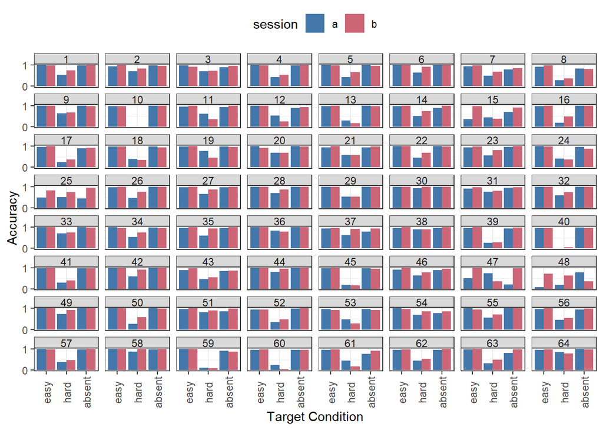

(#fig:acc_plt) Accuracy data for each participant for the split-half paradigm.

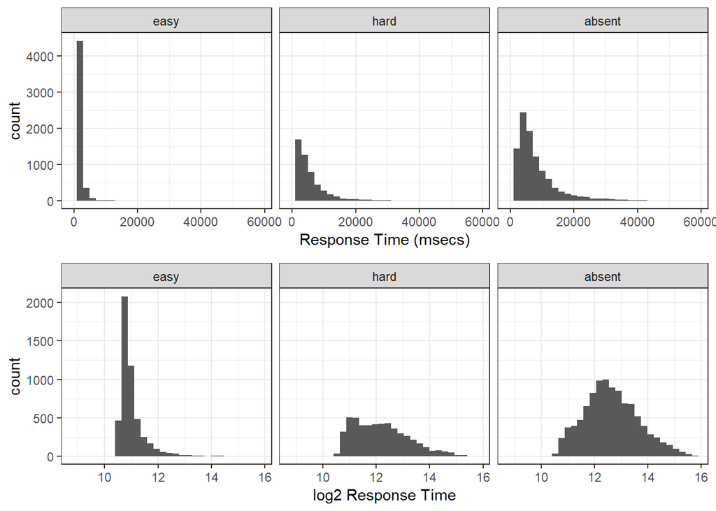

(#fig:rt_plt) Distribution of reaction times in split-half paradigm.

# 3 Data Processing

## 3.1 Split-Half

286 trials with invalid key responses were removed. After removing data from the four outlier participants (see above), all remaining incorrect trials (n = 2591) were removed, leaving a total of 16335 trials over 60 participants.

### 3.1.2 Eye Movements

420564 fixations were recorded. Of these, 4283 fell outside of the stimuli area and were removed. Fixations landing within a vertical strip consisting of 10% of the stimuli’s width were classed as central. All remaining fixations were then classed as landing on the homogeneous or heterogeneous half of the stimulus. Initial fixations were not included in the analysis. Numbers of fixations are given in Table 2.

| targSide | fix_loc | 1 < n | 2 <= n <= 5 |
| --- | --- | --- | --- |
| easy | central | 10152 | 5485 |
| easy | heterogenous | 5157 | 5005 |
| easy | homogenous | 5736 | 5622 |
| hard | central | 11385 | 6539 |
| hard | heterogenous | 6877 | 6701 |
| hard | homogenous | 6783 | 6655 |
| absent | central | 22664 | 13199 |
| absent | heterogenous | 12899 | 12600 |
| absent | homogenous | 13651 | 13405 |

## 3.2 Adaptive Choice

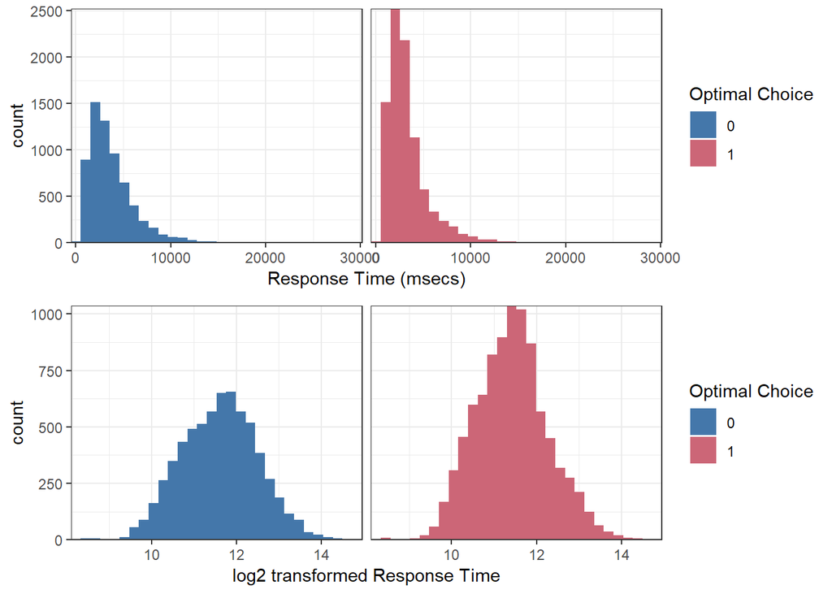

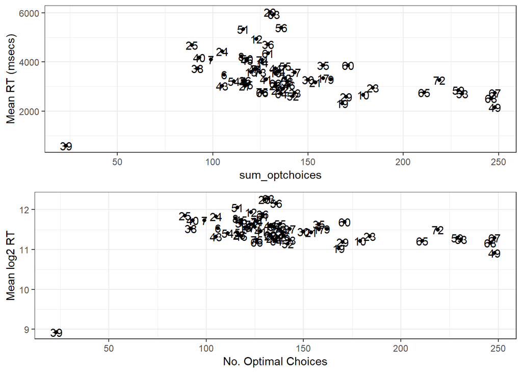

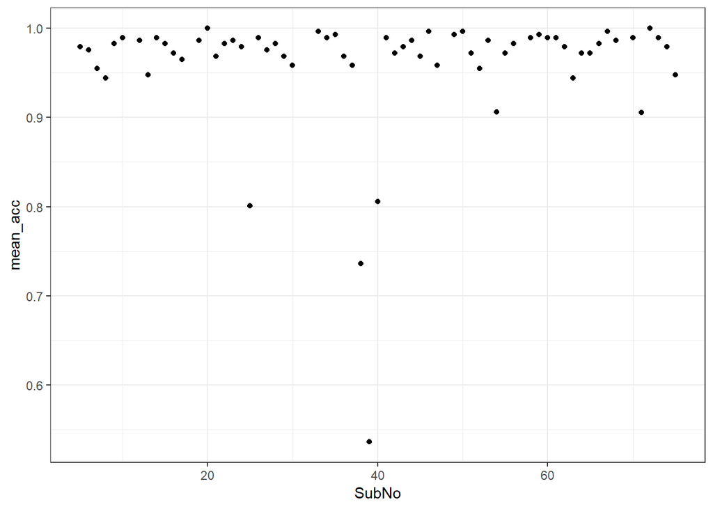

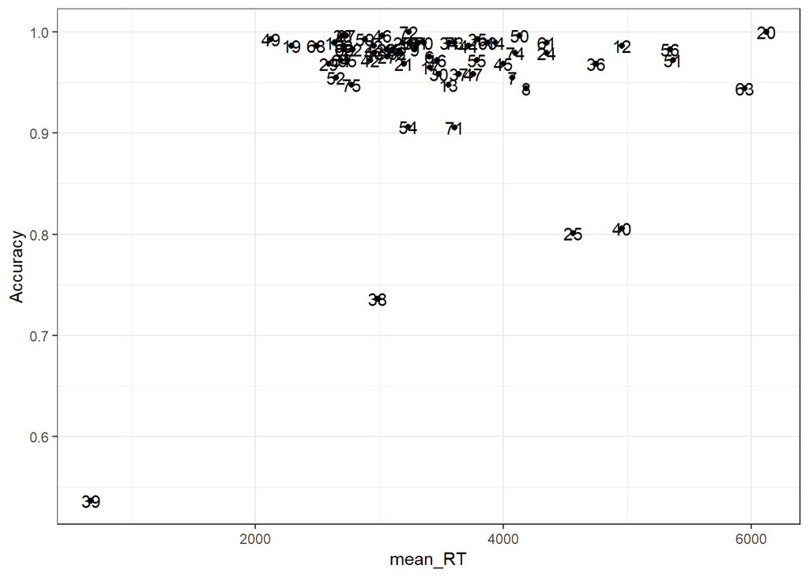

## 3.3 Foraging

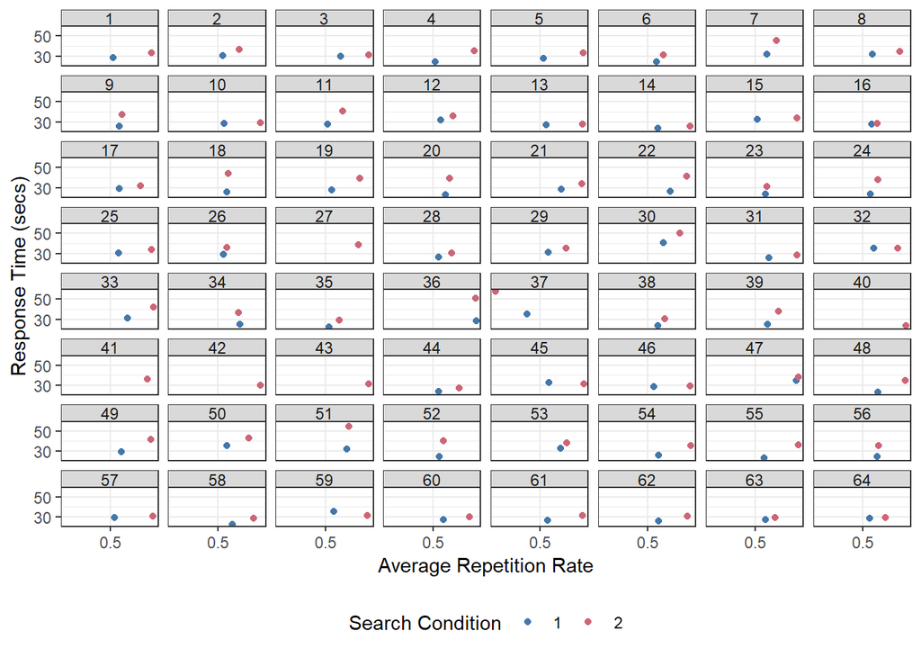